# Lab 6: Airport Data Science

Brian Teklits, Charles Doremieux, Andrew MacLean, Clint LaBattaglia

10/4/2019

```r
# function to convert from month/day to total days in year
month_day_to_days <- function(month){
  if(month==1){
    days = 0
  } else if(month==2){
    days = 31
  } else if(month==3){
    days = 31+28
  } else if(month==4){
    days = 31+28+31
  } else if(month==5){
    days = 31+28+31+30
  } else if(month==6){
    days = 31+28+31+30+31
  } else if(month==7){
    days = 31+28+31+30+31+30
  } else if(month==8){
    days = 31+28+31+30+31+30+31
  } else if(month==9){
    days = 31+28+31+30+31+30+31+31
  } else if(month==10){
    days = 31+28+31+30+31+30+31+31+30
  } else if(month==11){
    days = 31+28+31+30+31+30+31+31+30+31
  } else {
    days = 31+28+31+30+31+30+31+31+30+31+30
  }
  return(days)
}

# Apply function to the dataset
days <- DEN_flights %>%
  mutate(day_of_year = mapply(month_day_to_days,MONTH)+DAY_OF_MONTH)

# Count total flights for all 365 days
flights_per_Day <- days %>%
  group_by(day_of_year) %>%
  summarise(flightcount = n())
# Count total delayed flights for 365 days
delays_per_Day <- days %>%
  group_by(day_of_year) %>%
  filter(ARR_DELAY >= 15) %>%
  summarise(flightcount = n())
# combine above data frames into new data frame containing days and probability of delay per day
P_daily_delay <- cbind(flights_per_Day[1],(delays_per_Day[-1]/flights_per_Day[-1]))
```

### What Factors Lead to On-time Arrivals in Denver?

**Why this question is important:** Delayed flights cause a snowball effect of negative outcomes, affecting everyone at an airport. Travelers can miss flights altogether, runway traffic builds up, stressing both airport employees and air travelers. Analyzing the causes of flight delays can help us reduce the overall strain they cause on an airport.

**Why the answer is relevant:** Understanding the causes of delayed flights allows us to make predictions on when to expect future delays, as well as informing decisions on how to prevent delays when possible. Eliminating preventable delays and anticipating predictable delays can lead to a smoother airport experience for both travelers and employees.

### Team Plot and Findings

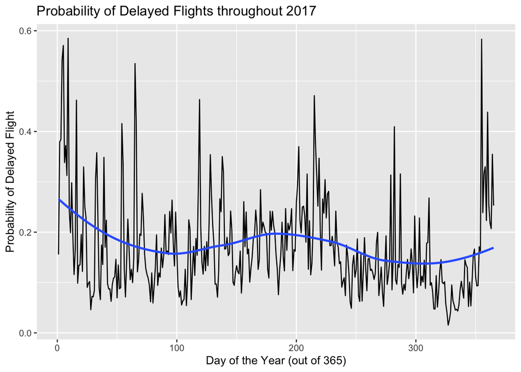

```r
ggplot(P_daily_delay,aes(day_of_year,flightcount))+
  geom_line()+
  geom_smooth(se=FALSE)+
  xlab("Day of the Year (out of 365)")+
  ylab("Probability of Delayed Flight")+
  ggtitle("Probability of Delayed Flights throughout 2017")
```

This plot shows a few interesting features. First, we note that the time of year predicts periodic increases and decreases in delays. Delays are more common towards the beginning and end of the year and during the summer months, when overall travel increases. Second, there are periodic changes on a smaller scale as well, suggesting delays may relate to day of the week, or time of month. Finally, there are random spikes throughout, either from specific days of the year (Christmas), or due to other non-time related factors.

### Recommendations

Time of week, time of year, and carrier all influence the probability a flight is delayed. People want to travel around holidays and prior to the weekend; convincing travelers to alter their travel plans to avoid delays will be difficult. Airlines can incentivize offday (Saturday, Sunday) and offyear (Spring, Fall) travel to attempt to smooth out the yearly bumps in delays around popular travel times.

The primary cause of delays at DIA is weather related. Certain carriers are better able to minimize delays from inclement weather. While cutting ties with an airline is not feasible, focusing on increasing partnerships with airlines such as Frontier, who sees a small percentage of their delays due to weather compared to other carriers, can help to minimize flight delays.

### Individual Sections

#### Andrew’s Plot

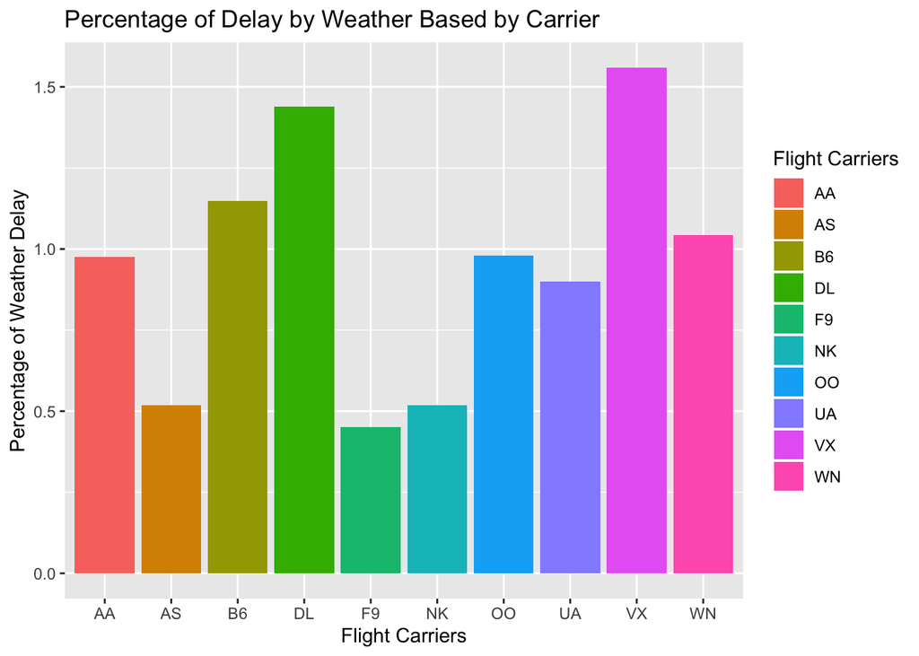

```r
delays_by_weather <- DEN_flights %>%
  group_by(CARRIER) %>%
  filter(WEATHER_DELAY > 14) %>%
  summarise(count = n())

delays_overall <- DEN_flights %>%
  group_by(CARRIER) %>%
  filter(ARR_TIME > 14) %>%
  summarise(overallcount = n())


P_weather_delay <- cbind(delays_overall[1],(delays_by_weather[-1]/delays_overall[-1]))


ggplot(P_weather_delay, mapping = aes(y= count*100, x = CARRIER))+
  geom_col(aes(fill = CARRIER))+
  scale_fill_discrete("Flight Carriers")+
  ylab("Percentage of Weather Delay")+
  xlab("Flight Carriers")+
  ggtitle("Percentage of Delay by Weather Based by Carrier")
```

Based off of this graph, you can tell which flights carriers were more likely to have weather delay on their flights. Weather delays are not a common occurence but based off this graph the difference between carrier could be massive. For example, the difference between carrier F9 and VX is about 700 flights. The factors that lead to more delays are based off the chance a flight carrier will have a weather delay. Our two factor are weather delays specifically and the flight carriers.

We can tell from this graph that some carriers might be more trustworthy to not have weather delays wither because of carrier policy or flight frequency. The other factor is weather delays and although they do not occur often, the differnce between around 1% in the plot is about 700 flights. That information displays that weather delays still affect amny flights.

#### Brian’s Plot

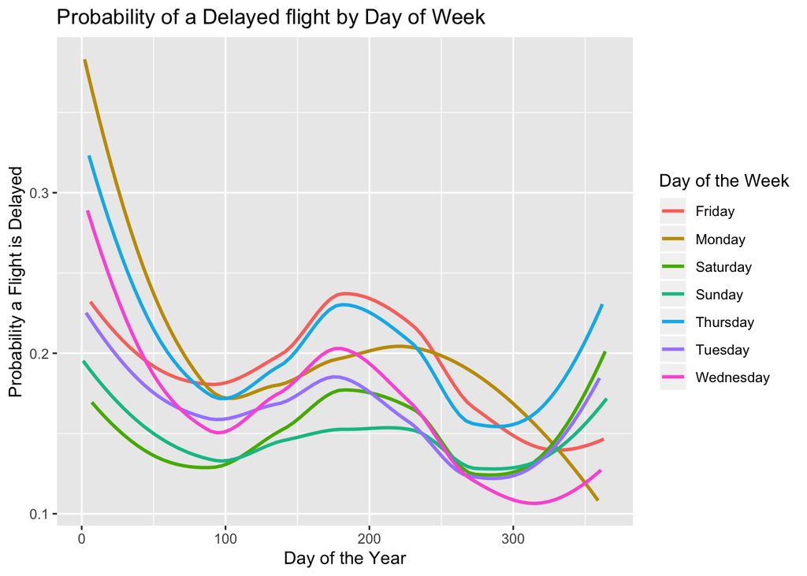

```r
# take days mod 7 to get day of week (1st of 2017 is sunday, so remainder 1 = sunday, remainder 2 = monday etc.)
P_weekday_delay <- P_daily_delay %>%
  mutate(week_day=day_of_year %% 7)

# map integers to weekday names
P_weekday_delay$week_dayname <- plyr::mapvalues(P_weekday_delay$week_day,
                           from = c(0,1,2,3,4,5,6),
                           to = c("Saturday","Sunday","Monday","Tuesday","Wednesday","Thursday","Friday"))

ggplot(P_weekday_delay,aes(day_of_year,flightcount,color=factor(week_dayname)))+
  geom_smooth(se=FALSE)+
  ggtitle("Probability of a Delayed flight by Day of Week")+
  ylab("Probability a Flight is Delayed")+
  xlab("Day of the Year")+
  scale_color_discrete("Day of the Week")
```

#### Charles’ Plot

```r
# the total amount of cancelled flights
t_cancel <- DEN_flights %>%
  filter(!is.na(CANCELLATION_CODE)) %>%
  #group_by(CANCELLATION_CODE) %>%
  summarize(count = n())
t_cancel
```

```
## # A tibble: 1 x 1
##   count
##   <int>
## 1  3070
```

```r
# the probability a cancelled flight is from reason A,B,C,D
a_cancel <- DEN_flights %>%
  filter(!is.na(CANCELLATION_CODE)) %>%
  group_by(CANCELLATION_CODE) %>%
  summarize(prob = n()/3070)

# map letters to reasons names
a_cancel$CANCELLATION_CODE <- plyr::mapvalues(a_cancel$CANCELLATION_CODE,
                           from = c('A','B','C','D'),
                           to = c("Carrier", "Weather", "National Air System", "Security"))
a_cancel
```

```
## # A tibble: 4 x 2
##   CANCELLATION_CODE      prob
##   <chr>                 <dbl>
## 1 Carrier             0.186
## 2 Weather             0.668
## 3 National Air System 0.144
## 4 Security            0.00130
```

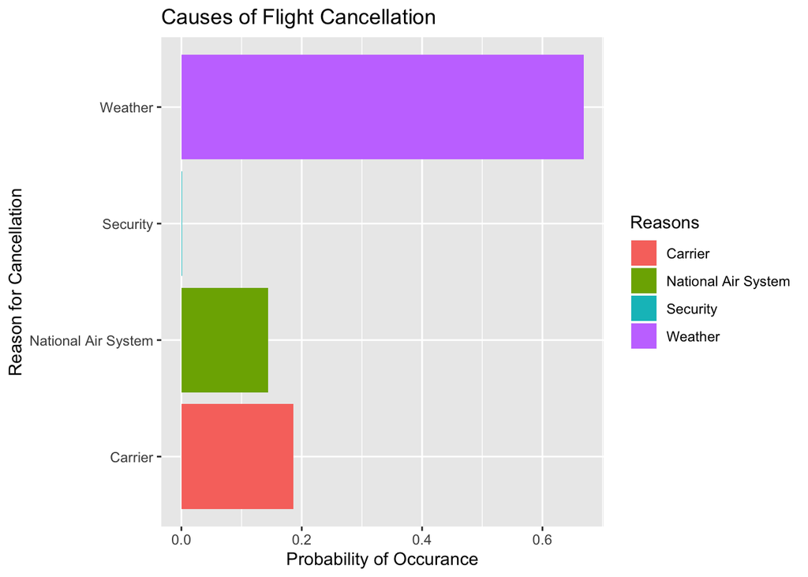

```r
ggplot(a_cancel)+
  geom_col(aes(x = CANCELLATION_CODE, y = prob, fill = CANCELLATION_CODE))+
  coord_flip()+
  ggtitle("Causes of Flight Cancellation")+
  ylab("Probability of Occurance")+
  xlab("Reason for Cancellation")+
  scale_fill_discrete("Reasons")
```

This graph demonstrates which cancellation ‘codes’ (i.e. Carrier, National Air System, Security, and Weather) are most likely to cause a flight cancellation. The rotated column graph demonstrates that the most common reasons for cancellation are weather problems and carrier causes (carrier chooses to cancel a flight).

#### Individual Contributions

**Brian:** I made the function to convert to total day of the year, as well as figuring out how to apply it to the data frame, and using cbind to be able to plot probabilities calculated from summarise. I used the non default scale_color_discrete to edit the title of my plot’s legend.

**Andrew:** I created a function to display the percentage that a flight carrier will have a flight delayed by the weather. I found that some carriers may be less trustworthy to delay a flight based off the weather than others. I also found that over weather flights are not that common but still affect many flights.

**Charles:** I compiled data structures related to the graphs involved in the lab. I generated a function which demonstrates that weather is the factor most predominantly linked to flight cancelation. From these results we were able to suggest that periods of travel should be determined mostly by period in the calendar year.